# Tugas Pertemuan 8

Irsyad Parama Dwiputra

2024-11-03

## Packages

```r
library(tidyverse)
library(forecast)
library(TSA)
library(aTSA)
library(car)
library(lmtest)
library(readxl)
```

## Pendahuluan

**Seasonal Autoregressive Integrated Moving Average (SARIMA)** merupakan pengembangan dari model Autoregressive Integrated Moving Average (ARIMA) pada data deret waktu yang memiliki pola musiman.

Model ARIMA musiman menggabungkan faktor-faktor non-musiman (regular) dan musiman dalam model multiplikasi, dengan notasi $ARIMA(p,d,q)×(P,D,Q)_s$ dengan:

- *p = non-seasonal AR order,*
- *d = non-seasonal differencing,*
- *q = non-seasonal MA order,*
- *P = seasonal AR order,*
- *D = seasonal differencing,*
- *Q = seasonal MA order,*
- *s = time span of repeating seasonal pattern.*

Tahapan identifikasi model SARIMA sama halnya seperti yang dilakukan pada model ARIMA regular atau model ARIMA non-seasonal, yaitu :

- Plot time series
- Identifikasi model
- Pendugaan parameter model
- Seleksi Model
- Melakukan peramalan menggunakan model terbaik

## Impor Data

```r
AP<-read_excel("C:/Users/Irsyad Parama/Downloads/AirPassengers.xlsx")
head(AP)
```

```
## # A tibble: 6 × 2
##   Month   X.Passengers
##   <chr>          <dbl>
## 1 1949-01          112
## 2 1949-02          118
## 3 1949-03          132
## 4 1949-04          129
## 5 1949-05          121
## 6 1949-06          135
```

```r
#View(AP)
```

```r
AP <- AP$X.Passengers
AP.ts<-ts(AP)
AP.ts
```

```
## Time Series:
## Start = 1
## End = 156
## Frequency = 1
##   [1] 112 118 132 129 121 135 148 148 136 119 104 118 115 126 141 135 125 149
##  [19] 170 170 158 133 114 140 145 150 178 163 172 178 199 199 184 162 146 166
##  [37] 171 180 193 181 183 218 230 242 209 191 172 194 196 196 236 235 229 243
##  [55] 264 272 237 211 180 201 204 188 235 227 234 264 302 293 259 229 203 229
##  [73] 242 233 267 269 270 315 364 347 312 274 237 278 284 277 317 313 318 374
##  [91] 413 405 355 306 271 306 315 301 356 348 355 422 465 467 404 347 305 336
## [109] 340 318 362 348 363 435 491 505 404 359 310 337 360 342 406 396 420 472
## [127] 548 559 463 407 362 405 417 391 419 461 472 535 622 606 508 461 390 432
## [145] 514 321 453 354 541 356 640 542 351 456 574 347
```

```r
class(AP.ts)
```

```
## [1] "ts"
```

## Eksplorasi Data

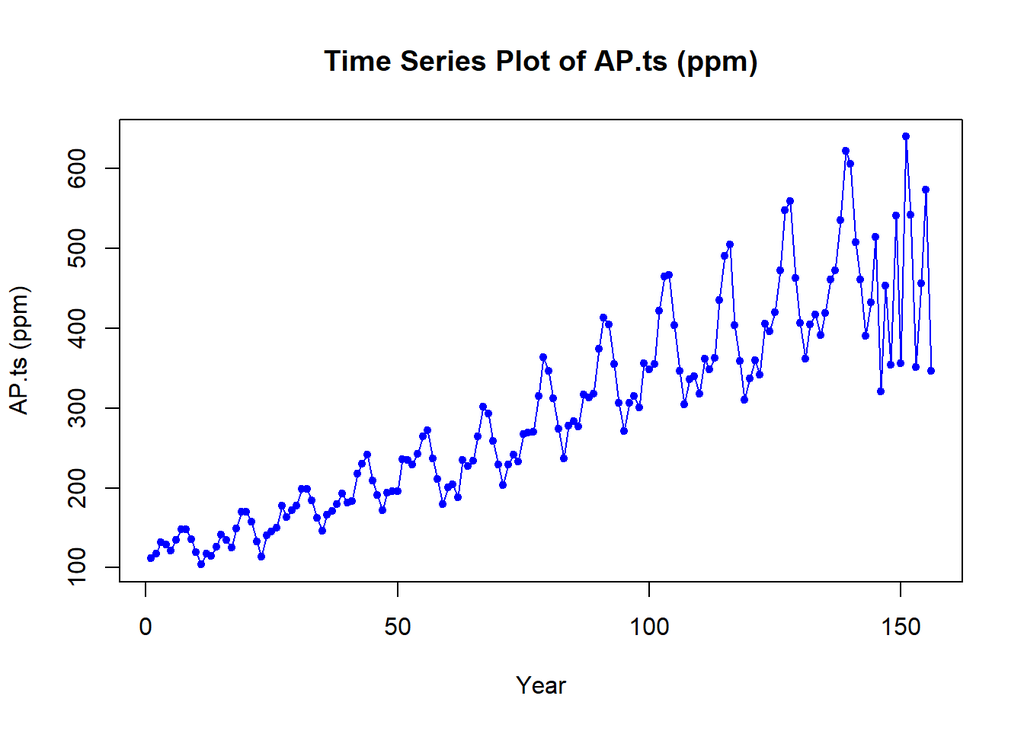

```r
ts.plot(AP.ts, type="l", xlab = "Year", ylab="AP.ts (ppm)", col="blue")
title(main = "Time Series Plot of AP.ts (ppm)", cex.sub = 0.8)
points(AP.ts, pch = 20, col = "blue")
```

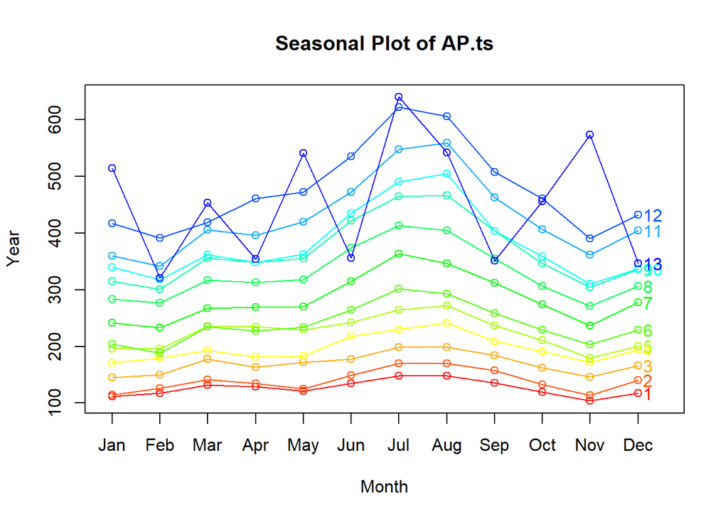

```r
seasonplot(AP.ts,12,main="Seasonal Plot of AP.ts", ylab="Year",
           year.labels = TRUE, col=rainbow(18))
```

Gambar menunjukkan bahwa penumpang yang naik pesawat tinggi pada bulan Juni, JUli, Agustus dan rendah pada bulan Februari, September, October, dan November . Perilaku tersebut terus berulang dari tahun ke tahun.

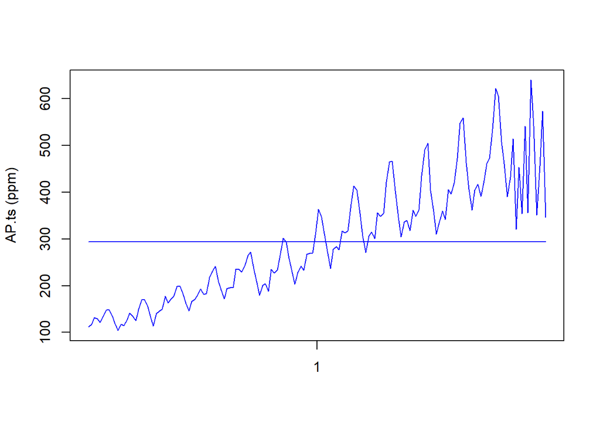

```r
monthplot(AP.ts,ylab="AP.ts (ppm)", col="blue")
```

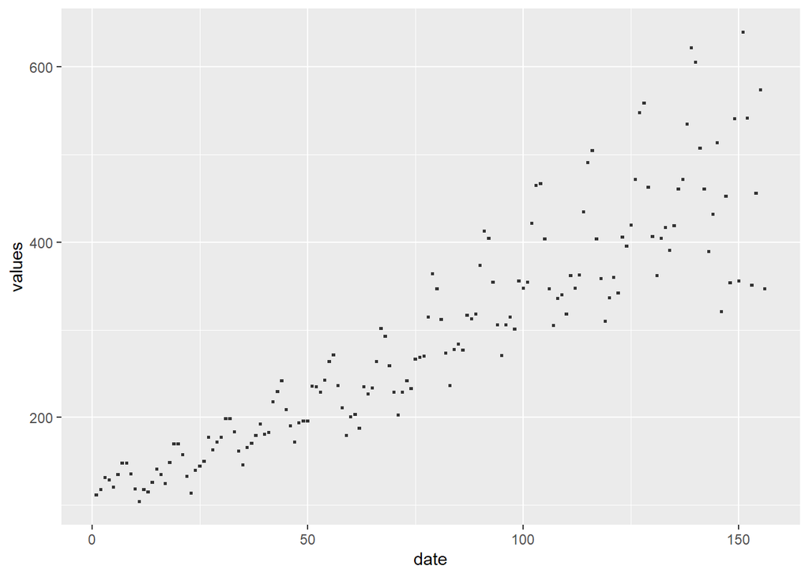

```r
frame<-data.frame(values=as.matrix(AP.ts), date=lubridate::year(zoo::as.Date(AP.ts)))

library(ggplot2)
ggplot(frame,aes(y=values,x=date,group=date))+
  geom_boxplot()
```

## Pembagian Data

```r
train.ts <- subset(AP.ts,start=1,end=126)
test.ts <- subset(AP.ts,start=127,end=157)
```

### Plot Data Latih

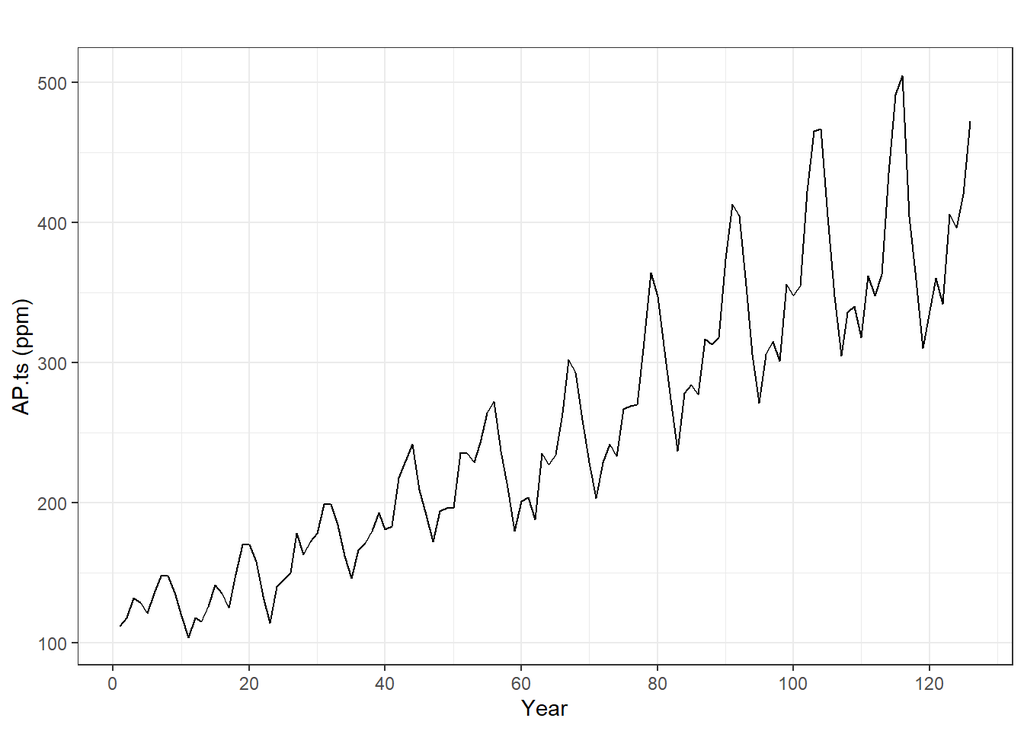

```r
autoplot(train.ts) + theme_bw() + xlab("Year") + ylab("AP.ts (ppm)")
```

### Plot Data Uji

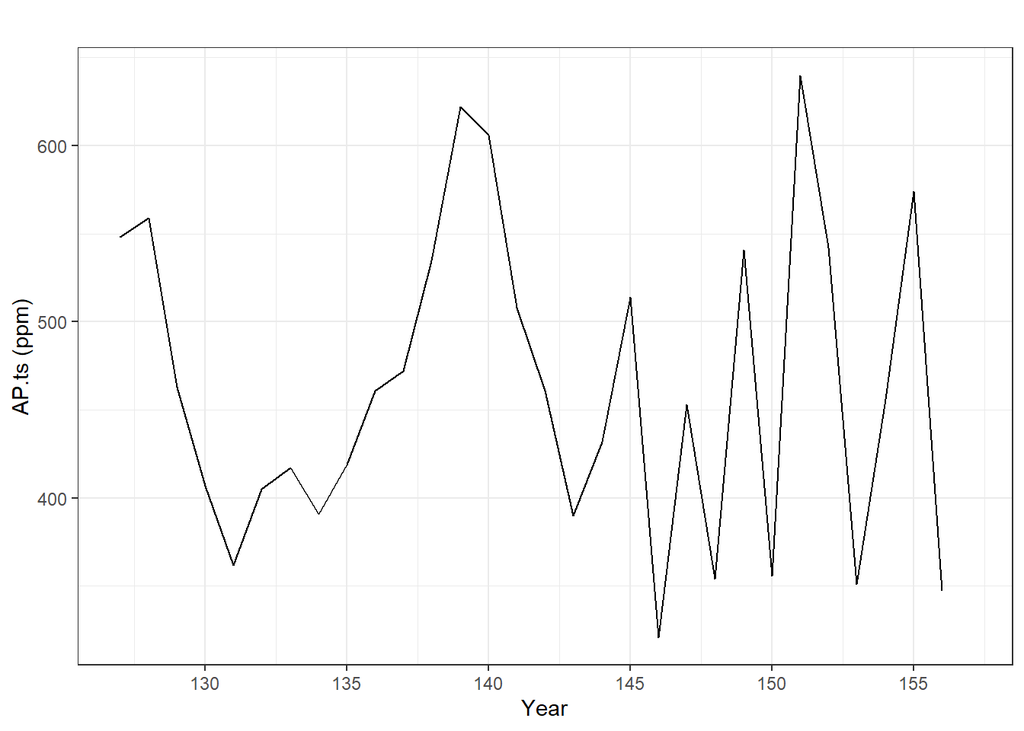

```r
autoplot(test.ts) + theme_bw() + xlab("Year") + ylab("AP.ts (ppm)")
```

## Non-Seasonal ARIMA

### Kestasioneran Data

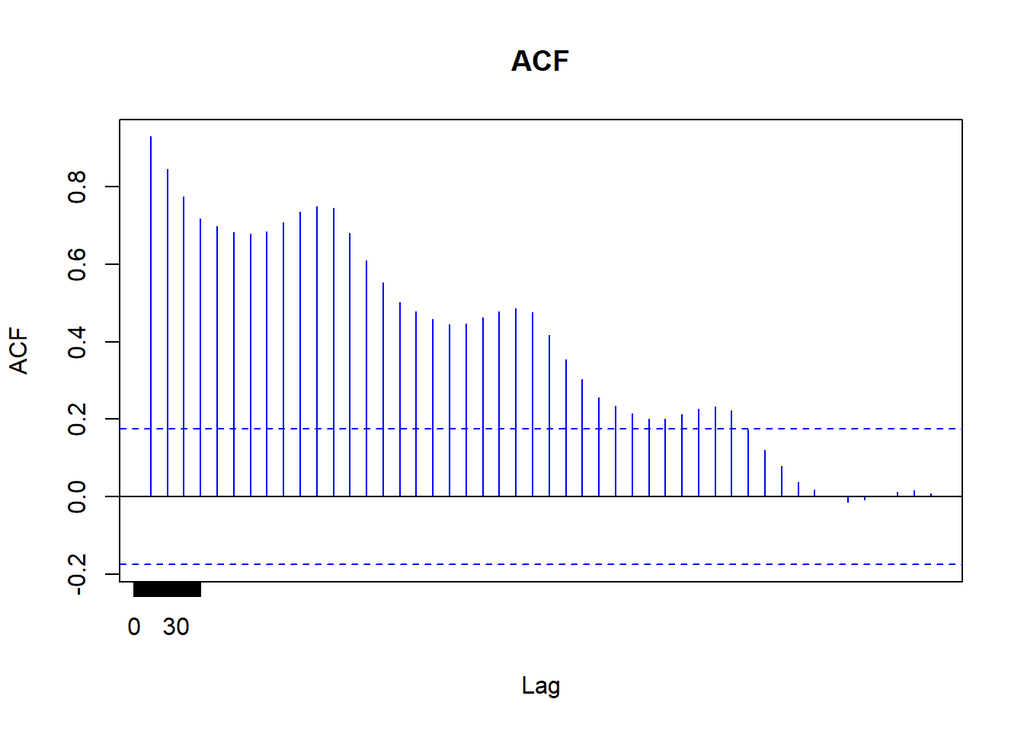

```r
acf0 <- acf(train.ts,main="ACF",lag.max=48,xaxt="n", col="blue")
axis(1, at=0:48/12, labels=0:48)
```

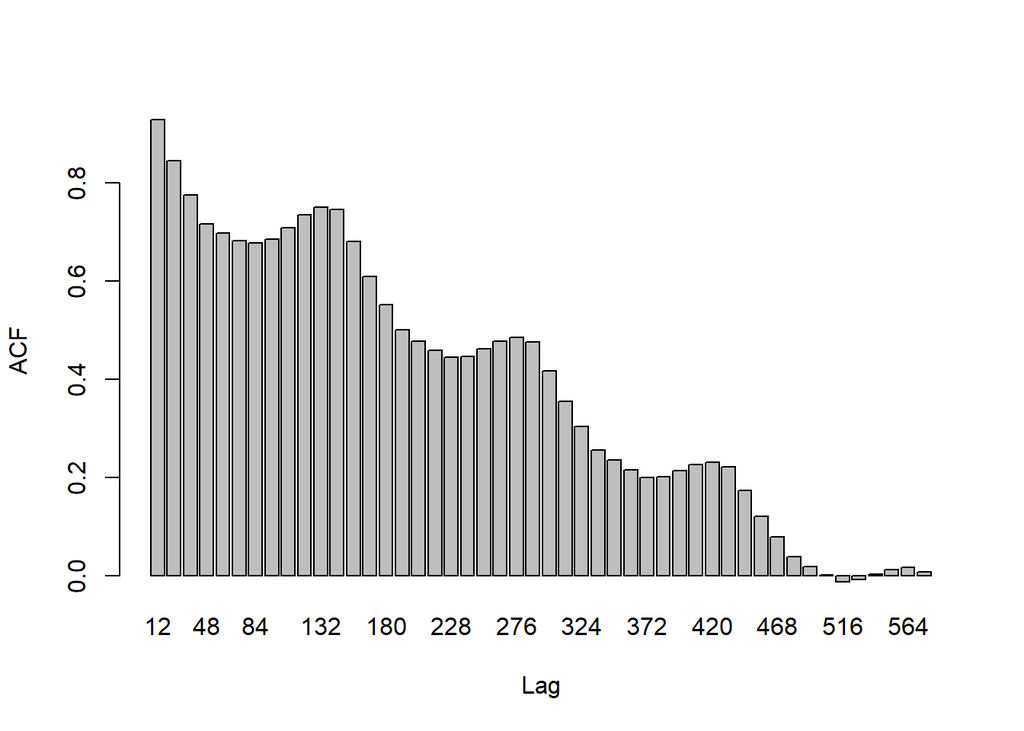

```r
acf0$lag <- acf0$lag * 12
acf0.1 <- as.data.frame(cbind(acf0$acf,acf0$lag))
acf0.2 <- acf0.1[which(acf0.1$V2%%12==0),]
barplot(height = acf0.2$V1,
names.arg=acf0.2$V2, ylab="ACF", xlab="Lag")
```

Berdasarkan plot deret sebelumnya diketahui bahwa perilaku deret berulang setiap tahun, atau dikatakan bahwa deret memiliki periode musiman bulanan, sehingga $s=12$. Perhatikan nilai fungsi autokorelasi pada lag-lag musiman (lag 12, 48, 84,…) dalam plot ACF contoh di atas. Tampak bahwa nilai autokorelasi pada lag-lag tersebut memiliki hubungan yang kuat. Bagaimanapun juga, plot ACF contoh meluruh secara perlahan dan membentuk pola gelombang kosinus teredam, yang menandakan ketidakstasioneran (plot deret juga menunjukkan adanya trend naik dalam deret).

```r
tseries::adf.test(train.ts)
```

```
##
##  Augmented Dickey-Fuller Test
##
## data:  train.ts
## Dickey-Fuller = -5.4877, Lag order = 4, p-value = 0.01
## alternative hypothesis: stationary
```

$H_0$ : Data tidak stasioner dalam rataan

$H_1$ : Data stasioner dalam rataan

### Pembedaan

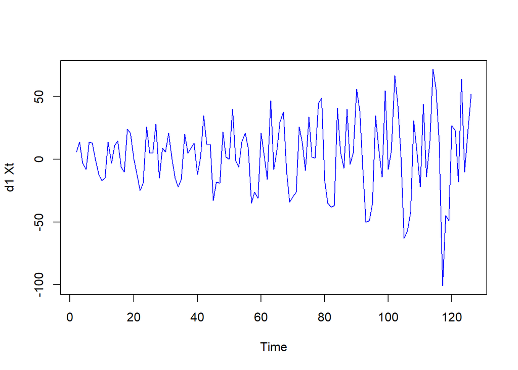

```r
d1 <- diff(train.ts)
ts.plot(d1, type="l", ylab="d1 Xt", col="blue")
```

*Differencing non-seasonal* $d=1$ jika dilihat berdasarkan plot di atas berhasil mengatasi ketidakstasioneran dalam rataan untuk komponen *non-seasonal*.

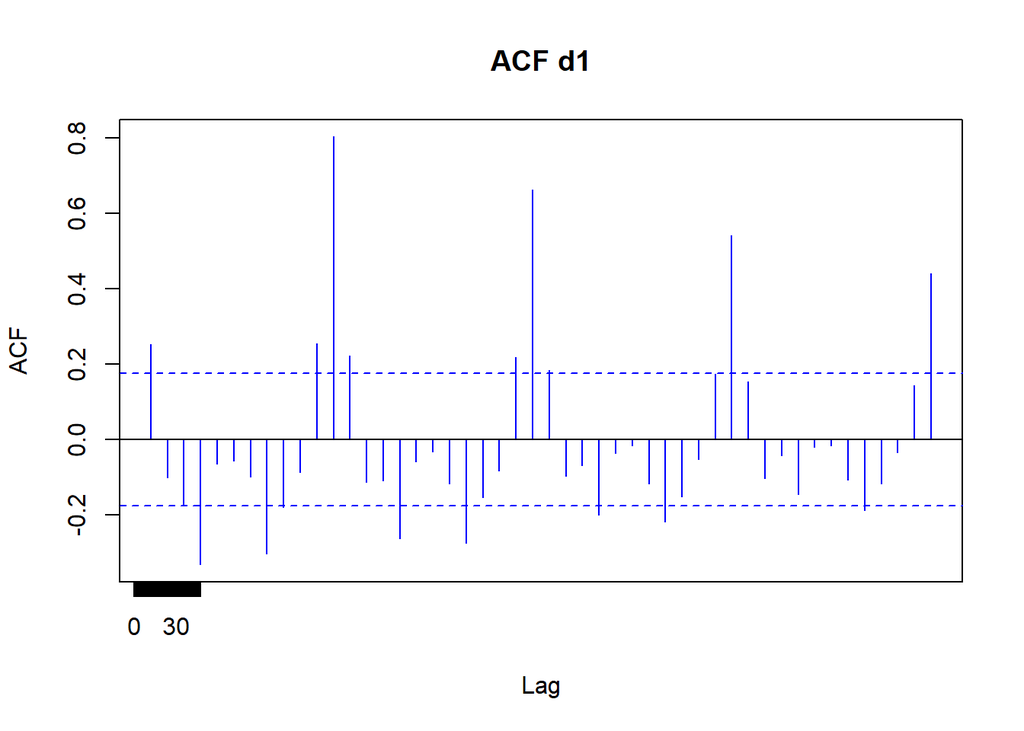

```r
acf1 <- acf(d1,lag.max=48,xaxt="n", main="ACF d1", col="blue")
axis(1, at=0:48/12, labels=0:48)
```

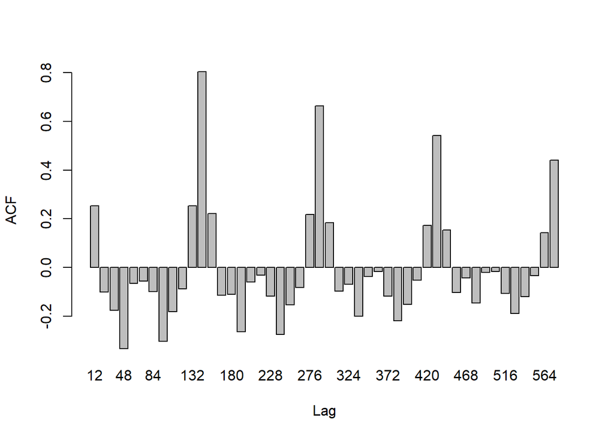

```r
acf2 <- acf1$lag <- acf1$lag * 12
acf1.1 <- as.data.frame(cbind(acf1$acf,acf1$lag))
acf1.2 <- acf1.1[which(acf1.1$V2%%12==0),]
barplot(height = acf1.2$V1, names.arg=acf1.2$V2, ylab="ACF", xlab="Lag")
```

Plot ACF data *non-seasonal differencing* $d=1$ mengkonfirmasi kestasioneran komponen *non-seasonal* (namun perhatikan lag 12,24, dst), pada *series* *seasonal* **belum stasioner**. Hal ini menunjukkan adanya kecenderungan musiman